# Tree Notebook

Last class we talked about Jupyter Notebooks. R notebooks are very similar. You actually can run R in Jupyter notebooks. You can do your full assignment in this notebook. Then, please save it as an HTML file and you are done.

In this assignment, you will learn about the various Tree based models that we covered in the past few weeks. As mentioned, Tree based models are a type of Machine Learning. They come to us from the field of computer science. They have some nice advantages:

*They provide a (usually) simple and easy to interpret display of the results that mimics human decision making (think decision trees)* They are quite adept at detecting the optimum break points for nonlinear variables (such as age in the Titanic example) *They are inherantly good at picking up multi layered “dependencies” that we call interaction terms.* Though the original tree is usually not very predictive, when trees are combined with boosting, bagging and decorrelation techniques they often are a top performing technique.

We are now in the world of predictive modelling. Our focus now is brute force prediction. In this world, even minor seeming improvements in predictive accuracy are important: they can translate into lives saved, millions earned, careers transformed. Every decimal counts for the person at the margin..

We will use the Titanic data because you are now familar with it. We are going to see if we can outdo the logistic regression results. So we will start with logistic regression as our base model. But this is no “strawman.” Logistic regression is a powerful technique that can often rise to the top. This method can be used for any problems that logistic regression takes on. You can use this method to predict any binary outcome.

So lets get started. First, lets load the required libraries. To run this code, press the little arrow in the upper right corner. We’ll load some tree packages as well as the caret package which is commonly used for cross validation

```r
library(Rcpp)
library(tree)
library(randomForest)
library(e1071)
library(caret)
library(pROC)
```

Now lets fire up a logistic regression model. The following code block will produce a decent example from the titanic example. Be careful to set the proper directory where you saved the titanic data on line *62*

```r
logisticPseudoR2s <- function(LogModel) {
  dev <- LogModel$deviance
  nullDev <- LogModel$null.deviance
  modelN <- length(LogModel$fitted.values)
  R.l <- 1 - dev / nullDev
  R.cs <- 1 - exp ( -(nullDev - dev) / modelN)
  R.n <- R.cs / (1 - ( exp (-(nullDev / modelN))))
  cat("Pseudo R^2 for Logistic Regression\n")
  cat("Hotitanicer and Lemeshow R^2 ", round(R.l, 3), "\n")
  cat("Cox and Snell R^2       ", round(R.cs, 3), "\n")
  cat("Nagelkerke R^2          ", round(R.n, 3),     "\n")
}
# Remove scientific notation
options(scipen=999)
# First, as always, set your working directory.
# setwd("c:/data")
# Next, load the data. This can be one of two ways, manually, or running the following code.
# Note: the following line of code only works if the file is located in your working directory.
train_set <- read.csv("train_set.csv")
# Let's remove NA's, as we have prior.
titanic <- train_set
titanic <- na.omit(titanic)
attach(titanic)
# Your data is loaded.
# View(titanic)
# Let's create an object, "Survived_value" and merge it into our dataset.
Survived_value = ifelse(Survived == 0, "No", "Yes")
titanic = data.frame(titanic, Survived_value)
# Your "titanic" data should include this "Survived_value" now.
# LOGISTIC MODEL -------------------------
# Let's reference how we completed this in the last assignment. Take a look at the below model.
# This model checks for a small child, a female, and the fare paid.
titanic$youngchild[titanic$Age <= 12] <- 1 ; titanic$youngchild[titanic$Age > 12] <- 0;
titanic$female[titanic$Sex == "male"] <- 0 ; titanic$female[titanic$Sex == "female"] <- 1;
# (1) Create Model
titanic_final <- glm(Survived ~ female + youngchild + Fare, family=binomial, data=titanic)
summary(titanic_final)
```

```
Call:
glm(formula = Survived ~ female + youngchild + Fare, family = binomial,
    data = titanic)

Deviance Residuals:
    Min       1Q   Median       3Q      Max
-2.3347  -0.6594  -0.6063   0.8248   1.9239

Coefficients:
             Estimate Std. Error z value             Pr(>|z|)
(Intercept) -1.679682   0.160370 -10.474 < 0.0000000000000002 ***
female       2.316858   0.210480  11.008 < 0.0000000000000002 ***
youngchild   0.478614   0.345864   1.384             0.166414
Fare         0.010174   0.002644   3.848             0.000119 ***
---
Signif. codes:  0 ‘***’ 0.001 ‘**’ 0.01 ‘*’ 0.05 ‘.’ 0.1 ‘ ’ 1

(Dispersion parameter for binomial family taken to be 1)

    Null deviance: 762.58  on 563  degrees of freedom
Residual deviance: 579.06  on 560  degrees of freedom
AIC: 587.06

Number of Fisher Scoring iterations: 4
```

```r
# (2) Run Diagnostics
exp(coef(titanic_final))
```

```
(Intercept)      female  youngchild        Fare
  0.1864333  10.1437508   1.6138353   1.0102261
```

```r
logisticPseudoR2s(titanic_final)
```

```
Pseudo R^2 for Logistic Regression
Hotitanicer and Lemeshow R^2  0.241
Cox and Snell R^2        0.278
Nagelkerke R^2           0.375
```

```r
# (3) Insert model probability into our dataset
prob_final = predict(titanic_final,type="response")
titanic$prob_final <- prob_final
quantile(titanic$prob_final)
```

```
       0%       25%       50%       75%      100%
0.1571376 0.1703134 0.2379446 0.6896401 0.9971276
```

```r
# (4) Predict "Survived" or "Died" based on model
pred_final = rep("No", 564) # Creates a vector of 564 "Died" elements
pred_final[titanic$prob_final>0.5] = "Yes" # Changes the "Died" elements to "Survived" if probability is above 0.5
pred_final[1:40]
```

```
 [1] "No"  "Yes" "Yes" "Yes" "No"  "No"  "No"  "Yes" "Yes" "Yes" "Yes" "No"  "No"  "Yes" "Yes" "No"  "Yes" "No"
[19] "No"  "Yes" "No"  "Yes" "Yes" "Yes" "No"  "No"  "No"  "No"  "No"  "Yes" "Yes" "Yes" "Yes" "Yes" "Yes" "Yes"
[37] "No"  "No"  "Yes" "Yes"
```

```r
titanic$pred_final <- pred_final
table(titanic$pred_final)
```

```
 No Yes
351 213
```

```r
table(pred_final,titanic$Survived_value) # Confusion table that compares our prediction to the Survived that was reality
```

```
pred_final  No Yes
       No  278  73
       Yes  56 157
```

```r
# Accuracy
table <- table(pred_final,titanic$Survived_value)
Accuracy <- sum(diag(table)/sum(table))
print(paste('Accuracy: ', Accuracy))
```

```
[1] "Accuracy:  0.771276595744681"
```

```r
# Calculate AUC and plot ROC curve
prob_log = predict(titanic_final, type ='response')
auc(titanic$Survived, prob_log)
```

```
Area under the curve: 0.8177
```

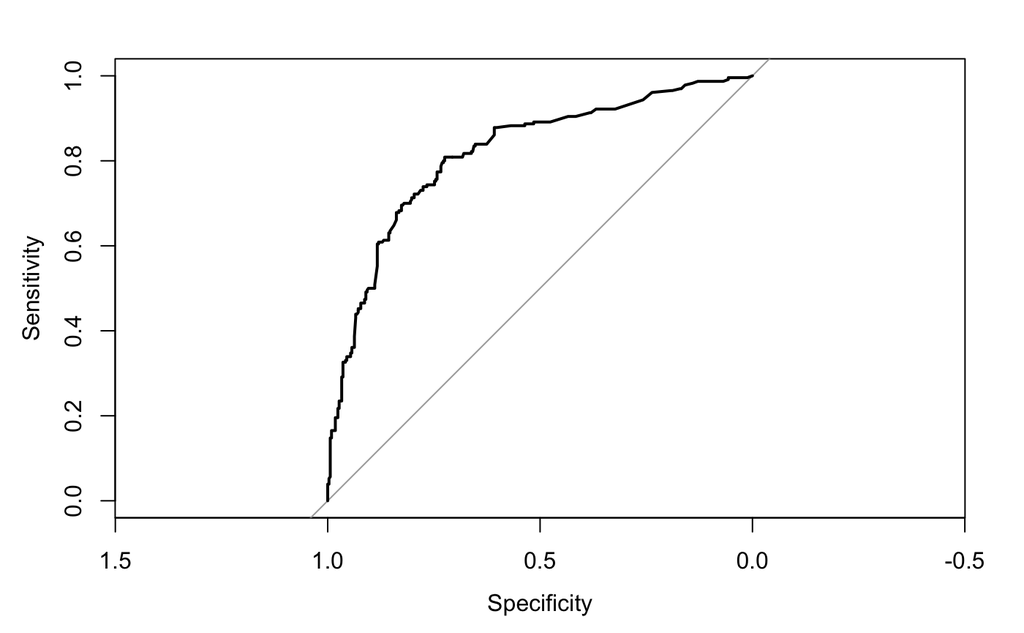

```r
plot(roc(titanic$Survived, prob_log))
```

*In this space below (before the next code block), report the accuracy of this model and the area under the curve. These are two different criteria. Explain what they tell you. This will be your baseline that we’ll try to improve with the tree models. Also, please describe the coeffecients in the model (what significant and what is the nature of the relationships?)

The accuracy of this model is 77.1%. This is the number of true positives + true negatives divided by the total number of observations.

The odds of survival are ….

```
… ~ 10.1 times greater if the passenger is a female vs male
… ~ 1.6 times greater if the passenger is a young child
```

Also, for each increase in fare (dollars) the odds of survival go up by a facror of 1.01.

The area under the curve tells us about specificity (X) vs. sensitivity (Y).  
The sensitivity is the probability of the model predicting “true” given that indeed the person survived. Specificity is the probability of the model predicting “false” given that observation indeed died. As we plot the area the curve, a more perfect model that discriminates very well would have both high sensitivity and specificity, which would be represented as the curve reaching as far into the top left corner as possible. A “useless” model, would hover over the diagnal lines.

In this Titantic example model, the model is “decent” or “pretty good”.

Let’s now move on to the next step. We will build a simple “starter” tree.

```r
# TREE GROWTH -------------------------
# (1) Starter Tree
# Let's create a tree using all our data to get our feet wet.
# This tree will not be tested, since we are leveraging all our data to create it.
starter_tree = tree( Survived_value ~ Pclass + Sex + Age + SibSp + Parch + Fare + Embarked, titanic)
summary(starter_tree)
```

```
Classification tree:
tree(formula = Survived_value ~ Pclass + Sex + Age + SibSp +
    Parch + Fare + Embarked, data = titanic)
Variables actually used in tree construction:
[1] "Sex"    "Pclass" "Fare"   "Age"    "SibSp"
Number of terminal nodes:  8
Residual mean deviance:  0.8171 = 454.3 / 556
Misclassification error rate: 0.1755 = 99 / 564
```

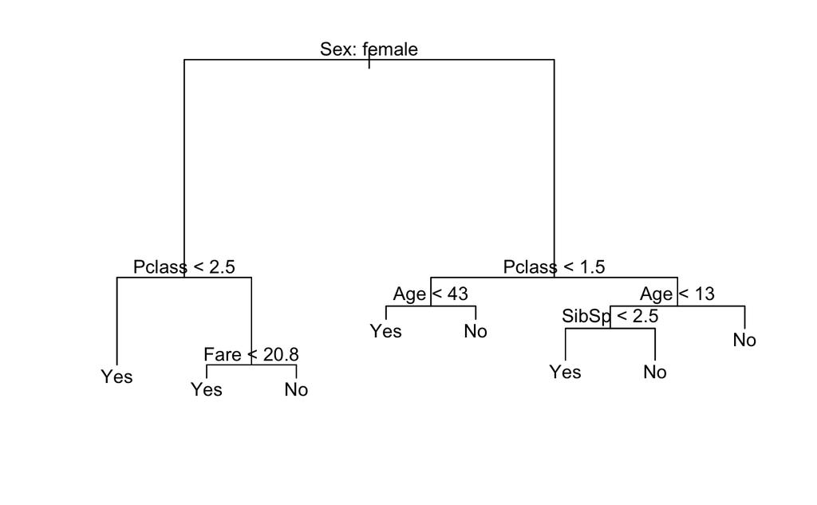

```r
# How many terminal nodes does this tree have? What does the misclassification error mean?
plot(starter_tree)
text(starter_tree, pretty=0)
```

```r
starter_tree
```

```
node), split, n, deviance, yval, (yprob)
      * denotes terminal node

 1) root 564 762.600 No ( 0.59220 0.40780 )
   2) Sex: female 207 233.400 Yes ( 0.25121 0.74879 )
     4) Pclass < 2.5 124  53.840 Yes ( 0.05645 0.94355 ) *
     5) Pclass > 2.5 83 114.500 No ( 0.54217 0.45783 )
      10) Fare < 20.8 64  88.160 Yes ( 0.45312 0.54688 ) *
      11) Fare > 20.8 19  16.570 No ( 0.84211 0.15789 ) *
   3) Sex: male 357 367.000 No ( 0.78992 0.21008 )
     6) Pclass < 1.5 86 115.400 No ( 0.60465 0.39535 )
      12) Age < 43 43  59.030 Yes ( 0.44186 0.55814 ) *
      13) Age > 43 43  46.640 No ( 0.76744 0.23256 ) *
     7) Pclass > 1.5 271 230.300 No ( 0.84871 0.15129 )
      14) Age < 13 22  30.500 Yes ( 0.50000 0.50000 )
        28) SibSp < 2.5 10   0.000 Yes ( 0.00000 1.00000 ) *
        29) SibSp > 2.5 12   6.884 No ( 0.91667 0.08333 ) *
      15) Age > 13 249 183.200 No ( 0.87952 0.12048 ) *
```

Using the lecture notes and the text, please explain what just happened. How does the tree work? How is it deciding which variables to split on and where to split. Please explain what is happening statistically. What is the significance (if any) of “sex” being the first split variable? For two of the leaves, describe the pathway of who ended up in the leaf. Open the output above in the “R console” view. Try to figure out how to interpret it. Which terminal node had the highest survival rate? Does it make sense based on what you know about the data? Which terminal node had the lowest survival rate?

Given the tree split first at sex, we can say sex is the most important variable in determining survival. The tree then split at class. We can say class is the second most important variable in determining survival. The length of the vertical line is how much contribution (or reduction in error) each variable provided. We can observe the longer line from sex to class, then from class to the next variables (age, fare, etc.). This gives us a sense of the greater importance of sex in the model than class and other variables.

Which terminal node had the highest survival rate? Does it make sense based on what you know about the data? Which terminal node had the lowest survival rate?

On the leaf furthest to the left, tracing from the top, we have females, then class < 2.5 meaning first or second class, the survived. So females who are first or second class survived. For the next leaf, we can see these are females who are 3rd class, and then the tree splits on fare. For those 3rd class females spending < 20.8 (presumably British pounds) this group survives. For the female 3rd class group spending more 20.8 pounds or more, they did not survive. This fare here may be serving as proxy for proximity to life boat access.

One of the flaws of the “entry level” decision tree is that they tend to “overfit” the data. At an extreme, they can memorize your dataset. In order to properly evaluate the performance of a classification tree on these data, we must estimate the test error rather than simply computing the training error.

To do that, we need to… (1) split observations into a training set and test set, (2) build the tree using the training set (3) evaluate its performance on the test data.

These steps play out below. As usual, we’ll set a “seed” value. This is a way of drawing a random sample but ensuring that we get the same result every time. We do that so that we can replicate our results. We will define a train sample, where we will build our tree. But, critically, we will test the tree on a “fresh” test sample. This is the fundamental takeway from “out of sample prediction” which is one of key key contributions of modern data science. So we’ll pull a sample of 200 in the training sample. The remainder will be in the test sample.

```r
# Split test/train
set.seed(2)
train = sample(1:nrow(titanic), 200)
test = titanic[-train,]
survived_test = Survived_value[-train]
```

How many people are in the test sample? Does that make sense??

Now lets look at the performance of this tree on “fresh” test data.

```r
# Create tree from training data (subset = 'train')
tree_train = tree( Survived_value ~ Pclass + Sex + Age + SibSp + Parch + Fare + Embarked, data = titanic, subset = train)
summary(tree_train)
```

```
Classification tree:
tree(formula = Survived_value ~ Pclass + Sex + Age + SibSp +
    Parch + Fare + Embarked, data = titanic, subset = train)
Variables actually used in tree construction:
[1] "Sex"    "Pclass" "Age"    "Fare"   "SibSp"
Number of terminal nodes:  14
Residual mean deviance:  0.7717 = 143.5 / 186
Misclassification error rate: 0.165 = 33 / 200
```

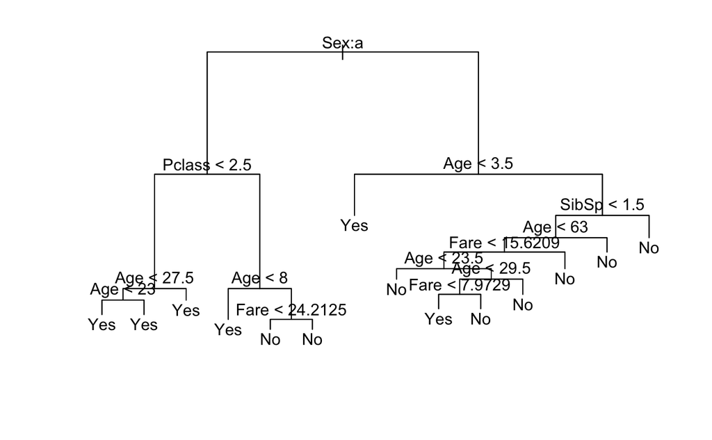

```r
plot(tree_train)
text(tree_train)
```

```r
# Evaluate performance on new data ('test')
train_pred = predict(tree_train, test, type="class")
confusionMatrix(train_pred, test$Survived_value)
```

```
Confusion Matrix and Statistics

          Reference
Prediction  No Yes
       No  186  62
       Yes  29  87

               Accuracy : 0.75
                 95% CI : (0.7022, 0.7937)
    No Information Rate : 0.5907
    P-Value [Acc > NIR] : 0.0000000001356

                  Kappa : 0.4648
 Mcnemar's Test P-Value : 0.0007951

            Sensitivity : 0.8651
            Specificity : 0.5839
         Pos Pred Value : 0.7500
         Neg Pred Value : 0.7500
             Prevalence : 0.5907
         Detection Rate : 0.5110
   Detection Prevalence : 0.6813
      Balanced Accuracy : 0.7245

       'Positive' Class : No
```

Now, comment on the overall accuracy of this starter tree? How does it compare to the logistic regression? Comment on some of the other diagnostics. What does the “sensitivity” mean? What about “specificity”? Google to remind your self what these terms mean. See https://www.theanalysisfactor.com/sensitivity-and-specificity/ or https://www.med.emory.edu/EMAC/curriculum/diagnosis/sensand.htm

This starter tree model has 75% accuracy. The logistic regression model earlier had 77% accuracy. We can be 95% confident the real model accuracy is between 70% and 79%. The p-value is low suggesting the model is significant at .001. Positive Prediction Value is at 75%. Positive Prediction Value is another word for precision which is calculated as the True positive / (True positive + False positive). Another way of saying this is given the items recalled (positive), how accurate was the model?

The sensitivity is the probability of the model predicting “true” given that indeed the person survived. Specificity is the probability of the model predicting “false” given that observed passengr indeed died.

Notice the tree that was produced above. There are many branches and leaves. This is what we’d call a “bushy” tree. It is likely still overfitting the data. Let us therefore “prune” the tree to get a more reliable results Although you may think more nodes is better, that often means overfitting, leading to poor test performance. A smaller tree with fewer splits could lead to better test results. This is achieved by pruning the tree.

```r
# PRUNING -------------------------
# cross validation will help us determine if pruning will improve importance (optimal level of tree complexity)
set.seed(3)
cv_titanic = cv.tree(tree_train,FUN=prune.misclass)
cv_titanic
```

```
$size
[1] 14 11  5  4  3  2  1

$dev
[1] 42 42 41 46 45 57 82

$k
[1] -Inf  0.0  0.5  4.0  5.0 10.0 26.0

$method
[1] "misclass"

attr(,"class")
[1] "prune"         "tree.sequence"
```

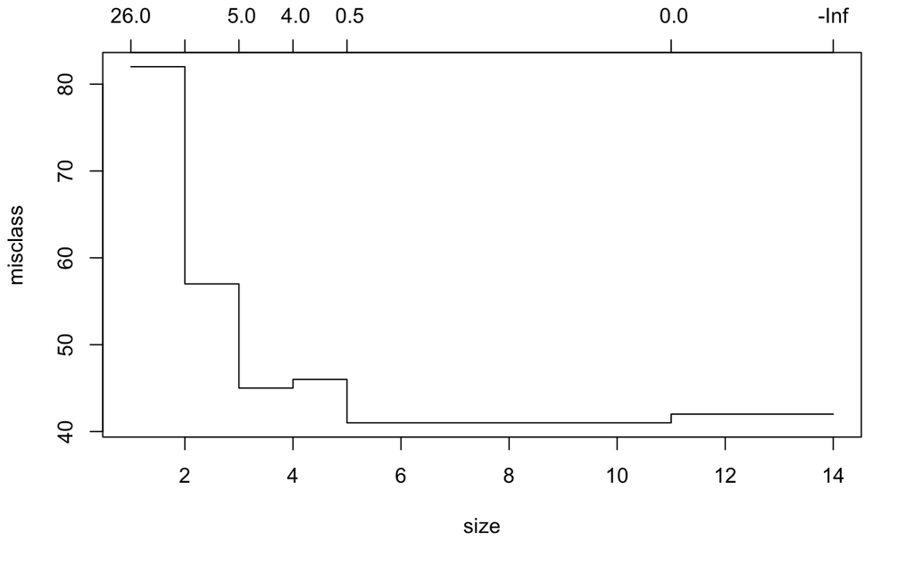

```r
# plot results to see the dev (cross-validation error rate) as a function of size and k
plot(cv_titanic)
par(mfrow=c(1,2))
```

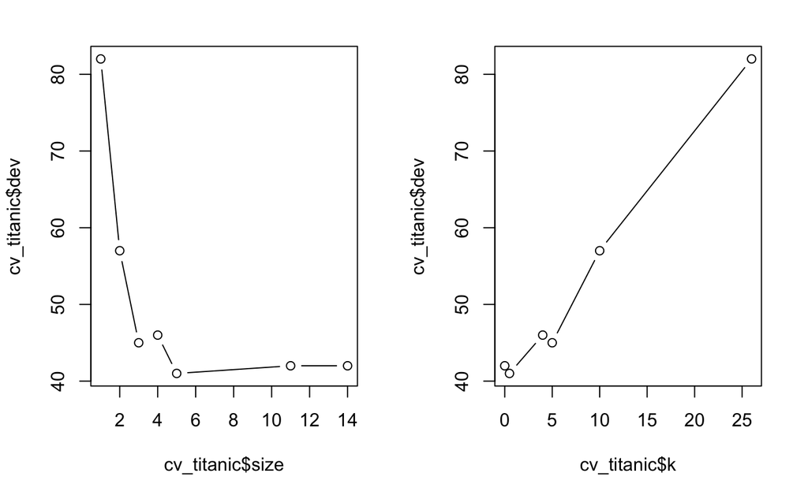

```r
plot(cv_titanic$size,cv_titanic$dev, type='b')
plot(cv_titanic$k,cv_titanic$dev,type='b')
```

```r
# We want to know which number of nodes results in the lowest cross-validation error rate
# now that we see that is 5, lets prune the tree to obtain a five-node tree
pruned_tree = prune.misclass(tree_train, best=5)
summary(pruned_tree)
```

```
Classification tree:
snip.tree(tree = tree_train, nodes = c(4L, 11L, 7L))
Variables actually used in tree construction:
[1] "Sex"    "Pclass" "Age"
Number of terminal nodes:  5
Residual mean deviance:  0.9276 = 180.9 / 195
Misclassification error rate: 0.18 = 36 / 200
```

```r
dev.off()
```

```r
plot(pruned_tree)
text(pruned_tree,pretty=0)
```

[figure not shown]

```r
# How does our pruned tree look different than our trained tree? Let's plot them side by side
par(mfrow=c(1,2))
```

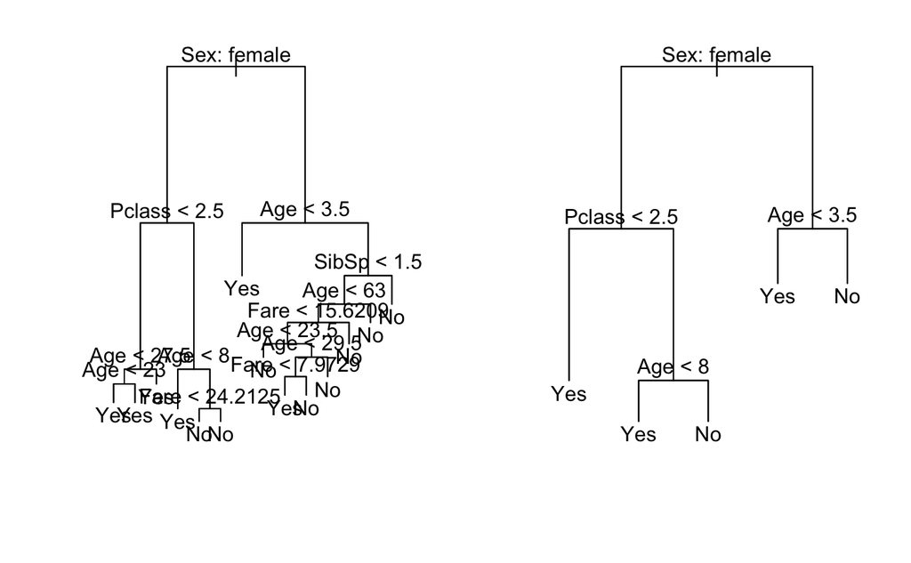

```r
plot(tree_train); text(tree_train, pretty=0)
plot(pruned_tree); text(pruned_tree,pretty=0)
```

```r
# test this pruned tree on the test data set
prune_pred = predict(pruned_tree, test, type='class')
confusionMatrix(prune_pred, test$Survived_value)
```

```
Confusion Matrix and Statistics

          Reference
Prediction  No Yes
       No  204  63
       Yes  11  86

               Accuracy : 0.7967
                 95% CI : (0.7516, 0.8369)
    No Information Rate : 0.5907
    P-Value [Acc > NIR] : < 0.00000000000000022

                  Kappa : 0.5558
 Mcnemar's Test P-Value : 0.000000003055

            Sensitivity : 0.9488
            Specificity : 0.5772
         Pos Pred Value : 0.7640
         Neg Pred Value : 0.8866
             Prevalence : 0.5907
         Detection Rate : 0.5604
   Detection Prevalence : 0.7335
      Balanced Accuracy : 0.7630

       'Positive' Class : No
```

Did the pruning improve the error? How about the accuracy? Looking at your text, the notes or the web explain some of the pruning options that we choose above and explain how pruning works.

Pruning is “cutting back the leafs and branches”. The common technique is called “weakest link pruning”. The prune.misclass “determines a nested sequence of subtrees of the supplied tree by recursively “snipping” off the least important splits” (from the R documentation). The key is to avoid building too complex a tree that “memorizes” the data set and performs poorly on out of sample data. By pruning the weak performing branches, we may introduce some bias into the model, but actually improve out of sample performance. This is done through the tuning parameter alpha. Setting alpha is basically making a tradeoff between model complexity and fit to the training data… the training data needs to be sampled so we can do this through cross-validation (trying multiple samples).

So far we’ve seen only minor improvements. The concepts of bagging, boosting and random forests are designed to turn trees from mediocre predictors into top rate algorithms.

# BAGGING ————————-

Bagging is our introduction to the concept of random forests. To apply bagging to regression trees, we bootstrap the training sets and average the resulting predictions. The code looks very similar to random forests, but we set mtry to the number of actual predictors, instead of a subest.

```r
set.seed(1)
bag_titanic = randomForest(Survived_value ~ Pclass + Sex + Age + SibSp + Parch + Fare + Embarked, data = titanic, subset = train, mtry=7, importance=TRUE)
bag_titanic
```

```
Call:
 randomForest(formula = Survived_value ~ Pclass + Sex + Age +      SibSp + Parch + Fare + Embarked, data = titanic, mtry = 7,      importance = TRUE, subset = train)
               Type of random forest: classification
                     Number of trees: 500
No. of variables tried at each split: 7

        OOB estimate of  error rate: 23.5%
Confusion matrix:
     No Yes class.error
No  102  17   0.1428571
Yes  30  51   0.3703704
```

```r
# What do you interpret from the OOB estimate of error rate? How about the classification error?
# Let's make predictions with the test set of data.
pred_bag = predict(bag_titanic, newdata = test)
confusionMatrix(pred_bag, test$Survived_value)
```

```
Confusion Matrix and Statistics

          Reference
Prediction  No Yes
       No  184  52
       Yes  31  97

               Accuracy : 0.772
                 95% CI : (0.7254, 0.8141)
    No Information Rate : 0.5907
    P-Value [Acc > NIR] : 0.0000000000002256

                  Kappa : 0.518
 Mcnemar's Test P-Value : 0.02814

            Sensitivity : 0.8558
            Specificity : 0.6510
         Pos Pred Value : 0.7797
         Neg Pred Value : 0.7578
             Prevalence : 0.5907
         Detection Rate : 0.5055
   Detection Prevalence : 0.6484
      Balanced Accuracy : 0.7534

       'Positive' Class : No
```

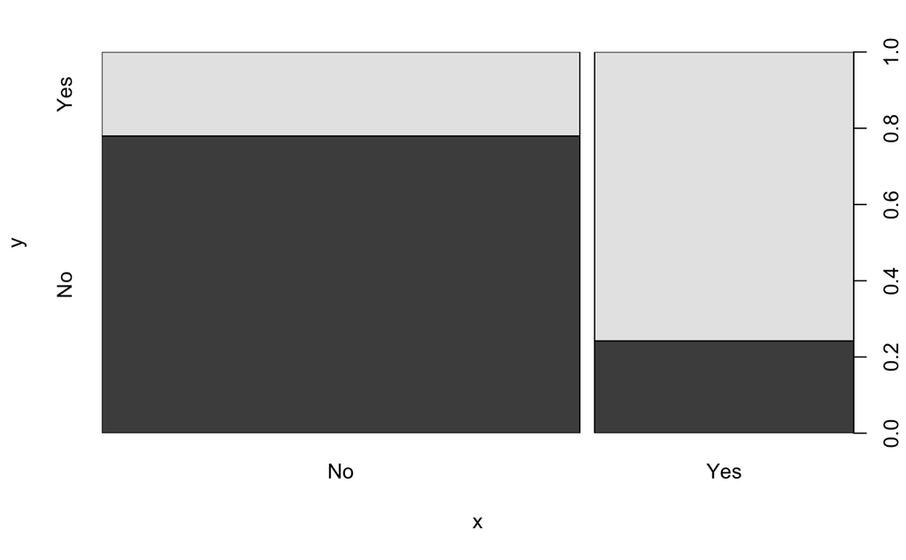

```r
#dev.off();
plot(pred_bag, test$Survived_value)
```

```r
# Accuracy
table <- table(pred_bag,test$Survived_value)
Accuracy <- sum(diag(table)/sum(table))
print(paste('Accuracy: ', Accuracy))
```

```
[1] "Accuracy:  0.771978021978022"
```

```r
# Plotting ROC curve
prob_bag = predict(bag_titanic, newdata = test, type ='prob')
auc(test$Survived, prob_bag[,2])
```

```
Area under the curve: 0.787
```

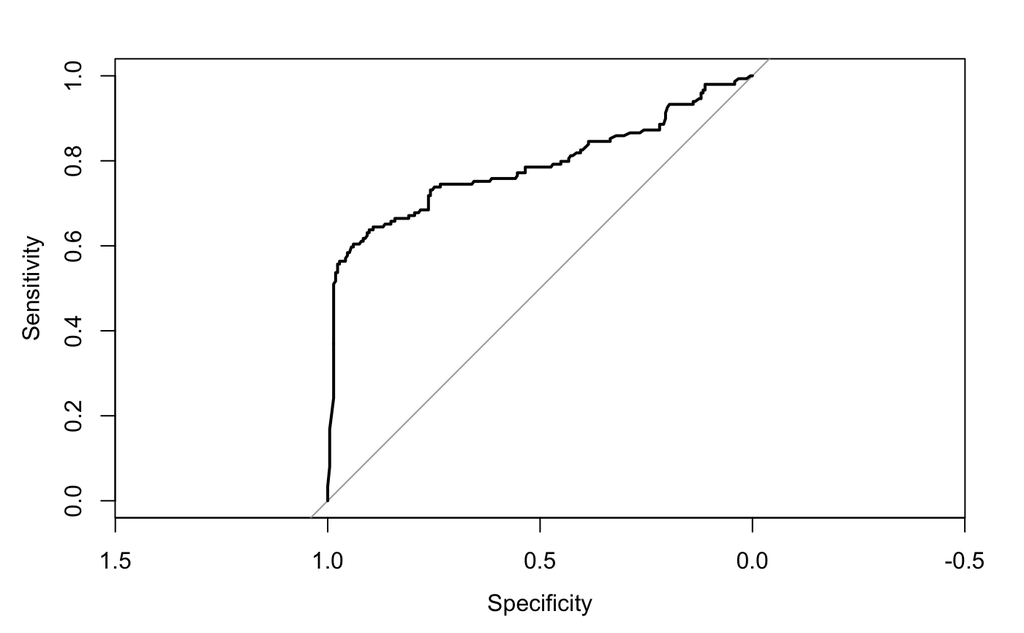

```r
plot(roc(test$Survived, prob_bag[,2]))
```

```r
# Did bagging improve the accuracy?
```

Did bagging improve the accuracy?

~77%, it actually seems to have gone down.

Answer above

To really get a boost, we will run a random forest. The key insight of random forests is similar to the key insight of portfolio diversification theory in finance. By “decorrelating” the decision trees we have a better chance of having a better solution. To accomplish this, random forests combining bagging (that is running lots of trees on bootstrap samples) with a decorrelation. At each branch, a typical random forest will only consider the square root of the variable set. For example, if you have 36 predictors, at each node, the procedure will consider only 6 of the variables for the optimal split. Lets see how this goes:

```r
# RANDOM FOREST -------------------------
# Now we will limit the number of predictors allowed using mtry
# Let's set it to 2 predictors and examine our results.
rf_titanic = randomForest(Survived_value ~ Pclass + Sex + Age + SibSp + Parch + Fare + Embarked, data= titanic, subset = train, mtry=2, importance=TRUE)
rf_titanic
```

```
Call:
 randomForest(formula = Survived_value ~ Pclass + Sex + Age +      SibSp + Parch + Fare + Embarked, data = titanic, mtry = 2,      importance = TRUE, subset = train)
               Type of random forest: classification
                     Number of trees: 500
No. of variables tried at each split: 2

        OOB estimate of  error rate: 24%
Confusion matrix:
     No Yes class.error
No  105  14   0.1176471
Yes  34  47   0.4197531
```

```r
# What do you interpret from the OOB estimate of error rate? How about the classification error?
# Let's make predictions with the test set of data.
pred_rf = predict(rf_titanic, newdata = test)
confusionMatrix(pred_rf, test$Survived_value)
```

```
Confusion Matrix and Statistics

          Reference
Prediction  No Yes
       No  197  51
       Yes  18  98

               Accuracy : 0.8104
                 95% CI : (0.7663, 0.8494)
    No Information Rate : 0.5907
    P-Value [Acc > NIR] : < 0.00000000000000022

                  Kappa : 0.5942
 Mcnemar's Test P-Value : 0.000117

            Sensitivity : 0.9163
            Specificity : 0.6577
         Pos Pred Value : 0.7944
         Neg Pred Value : 0.8448
             Prevalence : 0.5907
         Detection Rate : 0.5412
   Detection Prevalence : 0.6813
      Balanced Accuracy : 0.7870

       'Positive' Class : No
```

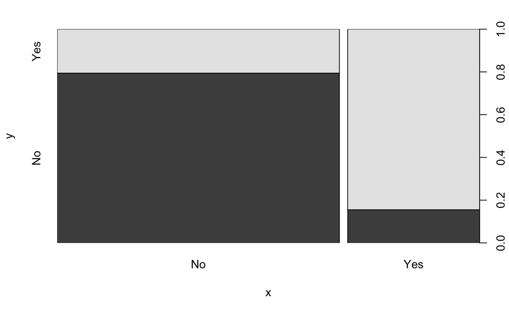

```r
plot(pred_rf, test$Survived_value)
```

```r
# Accuracy
table <- table(pred_rf,test$Survived_value)
Accuracy <- sum(diag(table)/sum(table))
print(paste('Accuracy: ', Accuracy))
```

```
[1] "Accuracy:  0.81043956043956"
```

```r
# Plotting ROC curve
prob_rf = predict(rf_titanic, newdata = test, type ='prob')
auc(test$Survived, prob_rf[,2])
```

```
Area under the curve: 0.809
```

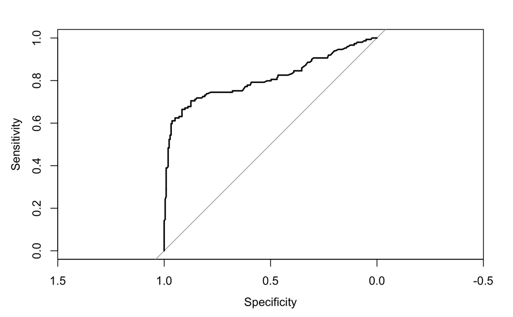

```r
plot(roc(test$Survived, prob_rf[,2]))
```

Did the accuracy improve?? Please explain how bagging, boosting and random forests improve prediction. Use the text and your notes to explain.

Yes, the ~81% this is the highest accuracy of the all the models tested thus far.

In bagging, we “create data” by taking repeated samples from a training set. We build separate prediction models from the population and average the predictions together. This reduces the variance in the model, so it is more likely to perform better.

Boosting actually is more sequential - we use information from the previous tree to make a better next tree. Also instead of resampling boosting involves we use a modified version the original data set. With bagging, we create a bunch of independent trees and combine. With boosting we slowly build trees that are based on the previous tree. More statistically we can say we fit the tree using the residuals, rather than the outcome variable - we take the “weak learners” resample, combine results, this updates the residuals. We can then repeat with a new tree.

Random forests are really ensembled decision trees. Similar to boosting, the trees are like the weak learners, and the random forest is the strong learner. At each split take random groups of the variables, this actually increases variablility in the data, and serves to decorrelate the variables.

We are now into the world of “black box” machine learning algorithms. We get a good prediction, but we are now using hundreds of trees on random subsets of variables to get this improvement. This is the price we pay for better predictions, but it is a big deal. Again, better predictions means fewer children with lead poisoning, fewer people unjustifiably incarcerated or misdiagnosed. But random forests do come with a nice tool for understanding what is driving the predictions. This is called the variable importance measure. We’ll run it below.

```r
# Examine the importance of each variable. What is your analysis?
importance(rf_titanic)
```

```
                No       Yes MeanDecreaseAccuracy MeanDecreaseGini
Pclass   12.868576 16.430050            20.630923         8.621119
Sex      23.668739 27.752943            33.281693        14.006302
Age      12.150391 10.468756            15.966728        20.721527
SibSp    14.073582 -1.579537            11.197684         6.231506
Parch     1.224784  2.253211             2.429234         5.079861
Fare     10.267189  6.982293            13.493720        19.827144
Embarked  1.254486 -4.403287            -1.594124         3.309376
```

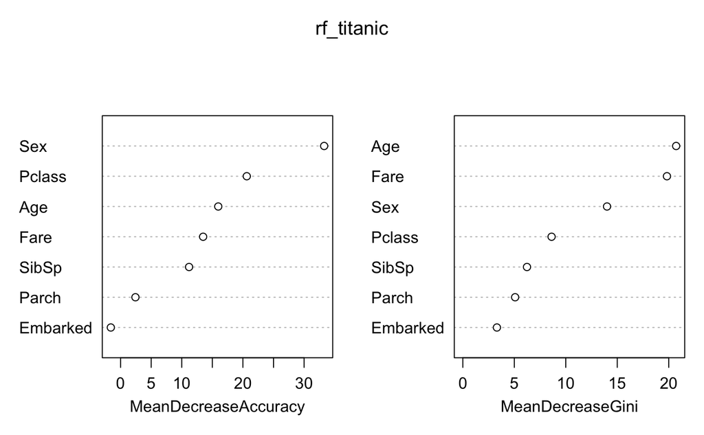

```r
varImpPlot(rf_titanic)
```

Interpret the output above. Any surprises? Do the results seem intutitive? using the book as a guide, explain how the variable importance statisics are derived.

Variable importance statistics records the amount of reduction in error that we can attribute to a given variable. Across the trees, we lok for variables that are the most important.

We know from the many models produced, sex and class are the most important variables, so the mean decrease accuracy chasrt is quite intuitive. For the mean decrease in Gini the way I understand this is that Gini is measuring the avererage gain of purity by splits. So we should interpret these two charts together and say while Sex is the most important variable from the overall accuracy, the Gini measures tell us if we were to remove Age or Fare we would be affecting the tree splits (especially after Sex) the most.

# ADVANCED EXTENSIONS ————————-

1. change the # of trees using ntree. First run with 2 trees, then with 25, then with 2500 trees then with 250,000 trees (this will take a few minutes to run depending on the power of your system). What happens to the accuracy at each step?

2 trees = accuracy 71.9% 20 trees = accuracy 78.0% 25 trees = accuracy 75.2% 250 trees = accuracy 76.9% 2500 trees = accuracy 78.5% 25,000 trees = accuracy 79.2% 250,000 trees = accuracy 79.2%

I ran these several times. Certainly wih 2-25 trees the results were similar but definitely had some variance due to the randomness in the model. Generally, as I add significantly more trees the model gets more accurate but you can see it also levels off (no difference between 25,000 and 250,000 for example) I tried to run 2,500,000 trees but it kept crashing R-studio.

Report your findings above.

```r
bag_titanic = randomForest(Survived_value ~ Pclass + Sex + Age + SibSp + Parch + Fare + Embarked, data=titanic, subset = train, mtry=7, ntree=250000)
pred_bag = predict(bag_titanic, newdata = test)
confusionMatrix(pred_bag, test$Survived_value)
```

```
Confusion Matrix and Statistics

          Reference
Prediction  No Yes
       No  189  50
       Yes  26  99

               Accuracy : 0.7912
                 95% CI : (0.7458, 0.8318)
    No Information Rate : 0.5907
    P-Value [Acc > NIR] : 0.0000000000000003742

                  Kappa : 0.5573
 Mcnemar's Test P-Value : 0.008333

            Sensitivity : 0.8791
            Specificity : 0.6644
         Pos Pred Value : 0.7908
         Neg Pred Value : 0.7920
             Prevalence : 0.5907
         Detection Rate : 0.5192
   Detection Prevalence : 0.6566
      Balanced Accuracy : 0.7717

       'Positive' Class : No
```

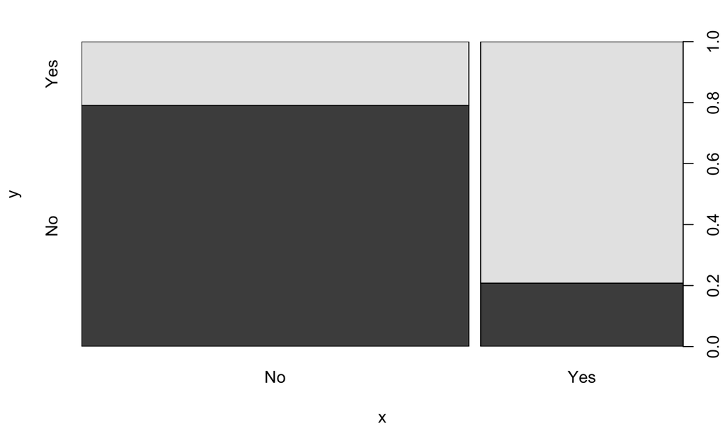

```r
#dev.off();
plot(pred_bag, test$Survived_value)
```

2. visualize the plots using rattle. The rattle plot is a state of the art visualization of trees. It is very nice but hard to run. Note: this will NOT WORK if you have the latest version of Mac. There are additional downloads required. Please email me (Ellie) if you would like to pursue this.

In the space above, describe the output from the rattle plot.

3. Change the number of predictors allowed in the random forest growth. Report on whether it changed the prediction accuracy. First use Mtry=4, then 6. Note, if you did the rattle plot above you need to now unintall the rattle package. Why do you think the accuracy is actually better when you try fewer variables? (think about the concept of decorrelation)

```r
# How are the results different when mtry is 4?
rf_titanic_4 = randomForest(Survived_value ~ Pclass + Sex + Age + SibSp + Parch + Fare + Embarked, data= titanic, subset = train, mtry=4, importance=TRUE)
rf_titanic_4
```

```
Call:
 randomForest(formula = Survived_value ~ Pclass + Sex + Age +      SibSp + Parch + Fare + Embarked, data = titanic, mtry = 4,      importance = TRUE, subset = train)
               Type of random forest: classification
                     Number of trees: 500
No. of variables tried at each split: 4

        OOB estimate of  error rate: 23%
Confusion matrix:
     No Yes class.error
No  103  16   0.1344538
Yes  30  51   0.3703704
```

```r
pred_rf_4 = predict(rf_titanic_4, newdata = test)
confusionMatrix(pred_rf_4, test$Survived_value)
```

```
Confusion Matrix and Statistics

          Reference
Prediction  No Yes
       No  192  51
       Yes  23  98

               Accuracy : 0.7967
                 95% CI : (0.7516, 0.8369)
    No Information Rate : 0.5907
    P-Value [Acc > NIR] : < 0.00000000000000022

                  Kappa : 0.5671
 Mcnemar's Test P-Value : 0.001697

            Sensitivity : 0.8930
            Specificity : 0.6577
         Pos Pred Value : 0.7901
         Neg Pred Value : 0.8099
             Prevalence : 0.5907
         Detection Rate : 0.5275
   Detection Prevalence : 0.6676
      Balanced Accuracy : 0.7754

       'Positive' Class : No
```

```r
table <- table(pred_rf_4,test$Survived_value)
Accuracy <- sum(diag(table)/sum(table))
print(paste('Accuracy: ', Accuracy))
```

```
[1] "Accuracy:  0.796703296703297"
```

```r
importance(rf_titanic_4)
```

```
                 No        Yes MeanDecreaseAccuracy MeanDecreaseGini
Pclass   16.8651759 21.4809895           28.5281875        11.797591
Sex      26.3303763 30.4713004           37.3734494        16.336822
Age      12.5646831 11.0418730           15.7357408        28.465836
SibSp    14.1861815 -1.3130862           12.1330532         5.949040
Parch     0.5054429  0.1925312            0.5206865         3.724288
Fare      6.9024644  3.9430083            8.6604594        24.640927
Embarked  0.5869619 -9.9220933           -4.8136169         2.885110
```

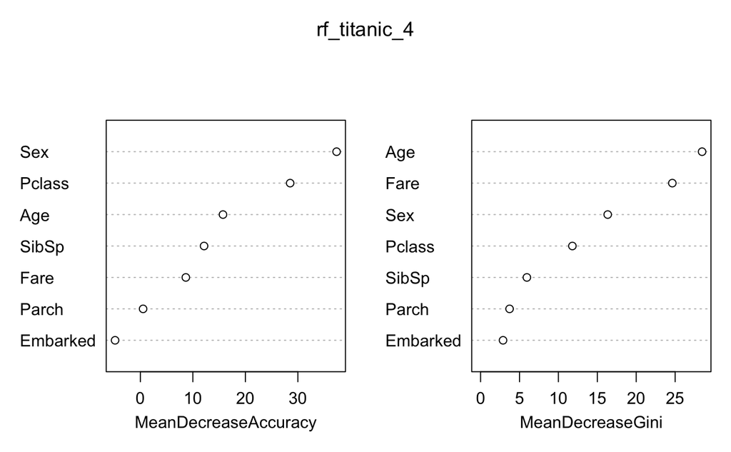

```r
varImpPlot(rf_titanic_4)
```

```r
# How are the results different when mtry is 6?
rf_titanic_6 = randomForest(Survived_value ~ Pclass + Sex + Age + SibSp + Parch + Fare + Embarked, data= titanic, subset = train, mtry=6, importance=TRUE)
rf_titanic_6
```

```
Call:
 randomForest(formula = Survived_value ~ Pclass + Sex + Age +      SibSp + Parch + Fare + Embarked, data = titanic, mtry = 6,      importance = TRUE, subset = train)
               Type of random forest: classification
                     Number of trees: 500
No. of variables tried at each split: 6

        OOB estimate of  error rate: 23.5%
Confusion matrix:
     No Yes class.error
No  103  16   0.1344538
Yes  31  50   0.3827160
```

```r
pred_rf_6 = predict(rf_titanic_6, newdata = test)
confusionMatrix(pred_rf_6, test$Survived_value)
```

```
Confusion Matrix and Statistics

          Reference
Prediction  No Yes
       No  188  52
       Yes  27  97

               Accuracy : 0.783
                 95% CI : (0.737, 0.8242)
    No Information Rate : 0.5907
    P-Value [Acc > NIR] : 0.000000000000006397

                  Kappa : 0.5393
 Mcnemar's Test P-Value : 0.00693

            Sensitivity : 0.8744
            Specificity : 0.6510
         Pos Pred Value : 0.7833
         Neg Pred Value : 0.7823
             Prevalence : 0.5907
         Detection Rate : 0.5165
   Detection Prevalence : 0.6593
      Balanced Accuracy : 0.7627

       'Positive' Class : No
```

```r
table <- table(pred_rf_6,test$Survived_value)
Accuracy <- sum(diag(table)/sum(table))
print(paste('Accuracy: ', Accuracy))
```

```
[1] "Accuracy:  0.782967032967033"
```

```r
importance(rf_titanic_6)
```

```
                 No       Yes MeanDecreaseAccuracy MeanDecreaseGini
Pclass   17.4188872 27.397882           31.9799341        13.555703
Sex      26.7026587 31.278427           39.3056844        17.177987
Age      13.9850285 14.276983           18.9915920        29.804411
SibSp    13.6770392 -1.696946           11.8465261         5.514539
Parch     2.7634036 -3.768171            0.3101825         2.613436
Fare      5.6930415  3.032305            6.9168678        24.589637
Embarked  0.4659915 -6.748605           -3.2932144         2.430872
```

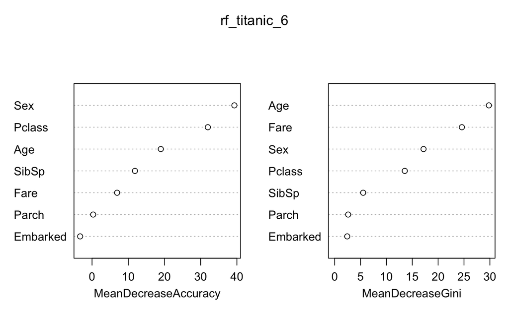

```r
varImpPlot(rf_titanic_6)
```

We will now try an advanced method called boosting. This is a sequential process where the model slowly “hones in” on cases that it is having trouble predicting. Look at the notes and the text and first note if boosting improved things and then explain a little more about how it works. Interpret all of the output.

```r
# (4) Boosting
# install.packages('gbm')
library(gbm)
set.seed(1)
boost_titanic = gbm(Survived ~ Pclass + Sex + Age + SibSp + Parch + Fare + Embarked, data= titanic[train,], distribution = "bernoulli", interaction.depth = 3, n.minobsinnode = 10, n.trees = 5000, shrinkage = 0.001, train.fraction = 0.8)
summary(boost_titanic)
```

|  | var | rel.inf |
| --- | --- | --- |
| Age | Age | 25.188927 |
| Sex | Sex | 22.821701 |
| Fare | Fare | 21.624976 |
| Pclass | Pclass | 19.579899 |
| SibSp | SibSp | 4.608298 |
| Parch | Parch | 3.739677 |
| Embarked | Embarked | 2.436522 |

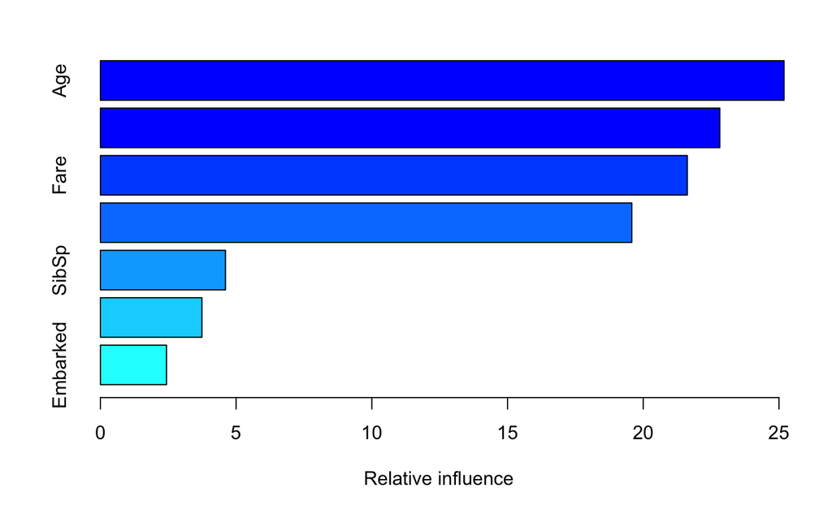

```r
# boost_titanic
prob_boost <- predict(boost_titanic, data= titanic[train,], n.trees = 5000, type = "response")
# prob_boost
par(mfrow=c(1,2))
```

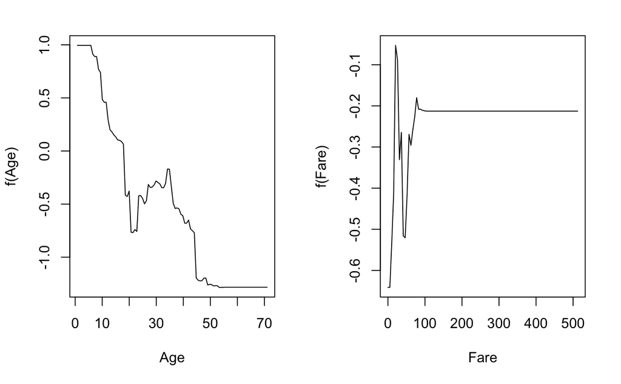

```r
plot(boost_titanic, i='Age')
plot(boost_titanic, i='Fare')
```

```r
survived_results <- rep('No', 404)
survived_results[test$Survived_value =='Yes'] = 'Yes'
survived_results
```

```
  [1] "No"  "Yes" "Yes" "No"  "No"  "Yes" "Yes" "No"  "Yes" "No"  "No"  "Yes" "No"  "Yes" "No"  "No"  "No"  "No"
 [19] "No"  "Yes" "No"  "Yes" "No"  "No"  "No"  "Yes" "Yes" "No"  "No"  "No"  "Yes" "Yes" "No"  "No"  "No"  "No"
 [37] "Yes" "No"  "Yes" "No"  "Yes" "Yes" "Yes" "No"  "No"  "No"  "No"  "No"  "No"  "Yes" "No"  "No"  "No"  "No"
 [55] "No"  "Yes" "No"  "Yes" "No"  "No"  "No"  "No"  "Yes" "No"  "No"  "Yes" "Yes" "No"  "No"  "No"  "No"  "No"
 [73] "Yes" "No"  "No"  "Yes" "No"  "Yes" "No"  "No"  "Yes" "No"  "No"  "No"  "No"  "No"  "No"  "Yes" "Yes" "No"
 [91] "Yes" "No"  "No"  "No"  "No"  "No"  "No"  "No"  "Yes" "Yes" "Yes" "No"  "No"  "Yes" "Yes" "No"  "Yes" "No"
[109] "Yes" "No"  "No"  "Yes" "No"  "No"  "Yes" "No"  "No"  "No"  "Yes" "No"  "No"  "Yes" "No"  "No"  "No"  "No"
[127] "Yes" "Yes" "Yes" "No"  "No"  "Yes" "Yes" "Yes" "No"  "Yes" "No"  "Yes" "No"  "No"  "No"  "Yes" "No"  "Yes"
[145] "Yes" "Yes" "Yes" "No"  "No"  "No"  "No"  "No"  "Yes" "No"  "Yes" "No"  "Yes" "Yes" "No"  "No"  "No"  "Yes"
[163] "Yes" "Yes" "No"  "No"  "Yes" "No"  "Yes" "Yes" "No"  "No"  "No"  "Yes" "Yes" "No"  "No"  "No"  "No"  "Yes"
[181] "No"  "No"  "No"  "No"  "No"  "No"  "No"  "No"  "No"  "No"  "Yes" "Yes" "Yes" "No"  "No"  "No"  "Yes" "No"
[199] "No"  "Yes" "No"  "Yes" "Yes" "Yes" "Yes" "Yes" "No"  "No"  "Yes" "Yes" "No"  "No"  "No"  "No"  "Yes" "No"
[217] "Yes" "No"  "No"  "No"  "No"  "No"  "Yes" "Yes" "Yes" "Yes" "Yes" "No"  "No"  "Yes" "No"  "Yes" "No"  "No"
[235] "Yes" "Yes" "Yes" "Yes" "No"  "Yes" "Yes" "Yes" "No"  "No"  "Yes" "No"  "Yes" "Yes" "No"  "No"  "No"  "Yes"
[253] "Yes" "Yes" "Yes" "No"  "Yes" "No"  "No"  "Yes" "No"  "No"  "Yes" "Yes" "No"  "No"  "No"  "No"  "No"  "Yes"
[271] "No"  "Yes" "Yes" "Yes" "No"  "Yes" "Yes" "No"  "Yes" "Yes" "No"  "Yes" "Yes" "No"  "Yes" "Yes" "Yes" "No"
[289] "No"  "Yes" "Yes" "Yes" "No"  "Yes" "Yes" "Yes" "Yes" "Yes" "No"  "No"  "No"  "No"  "No"  "No"  "Yes" "Yes"
[307] "No"  "No"  "Yes" "Yes" "Yes" "No"  "No"  "No"  "No"  "No"  "No"  "No"  "No"  "No"  "No"  "Yes" "No"  "No"
[325] "No"  "No"  "Yes" "No"  "Yes" "Yes" "Yes" "No"  "No"  "No"  "No"  "Yes" "No"  "No"  "No"  "No"  "No"  "No"
[343] "Yes" "No"  "Yes" "Yes" "No"  "No"  "No"  "No"  "Yes" "Yes" "No"  "No"  "No"  "No"  "Yes" "No"  "No"  "No"
[361] "Yes" "Yes" "Yes" "Yes" "No"  "Yes" "Yes" "No"  "No"  "Yes" "Yes" "No"  "Yes" "No"  "No"  "Yes" "No"  "Yes"
[379] "No"  "No"  "No"  "No"  "No"  "Yes" "No"  "Yes" "No"  "No"  "No"  "Yes" "Yes" "No"  "No"  "No"  "Yes" "Yes"
[397] "No"  "No"  "No"  "No"  "Yes" "No"  "Yes" "No"
```

```r
pred_boost = rep('No', 404)
pred_boost[prob_boost>0.5] = 'Yes'
# pred_boost
table(pred_boost, survived_results)
```

```
          survived_results
pred_boost  No Yes
       No  171 111
       Yes  69  53
```